# More Love, More Positive?

Hanbo JIAO

2020/2/2

# Introduction

The musics have played an important role in our daily life. In this project, we applied texting mining techniques to explore what artists expressed in their songs, what kind of sentiments they wanted to show based on the lyrics.

# Which words are used the most frequently in Pop Music?

In this part, I would like to find the most frequently used words in lyrics of Pop music. From the word cloud plot below, it shows that “love” is the most frequently word. It is reasonable because when people talk about musics, the first word that came to mind might be “love”.

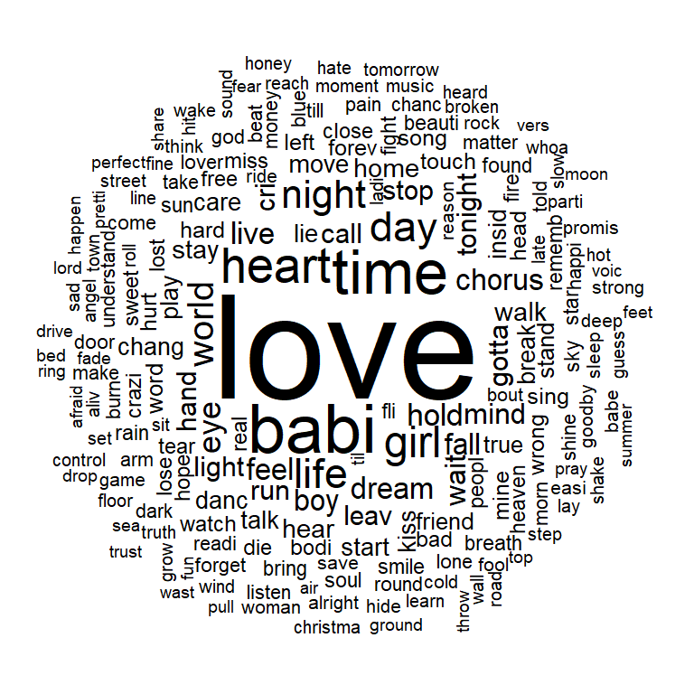

# Sentiment of songs

Artists write lyrics and sing songs because they can express their emotions and sentiments through lyrics. So sentiment analysis is used in our project. We use sentiment analysis based on “NRC” and “Bing” to figure out the emotions the words show.

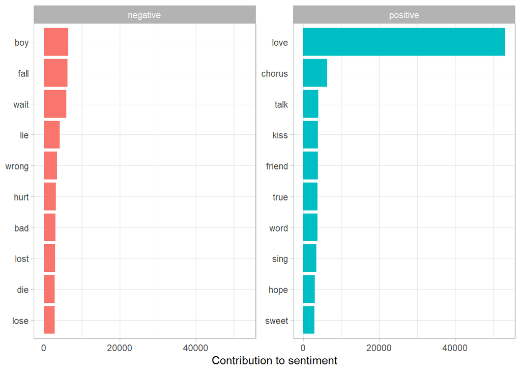

Next, we plot the word cloud for Pop music again. But we take the sentiment into account and separate the positive and negative words. Same as before, “love” is the most frequently used word. And we cannot conclude there are more positive word or not.

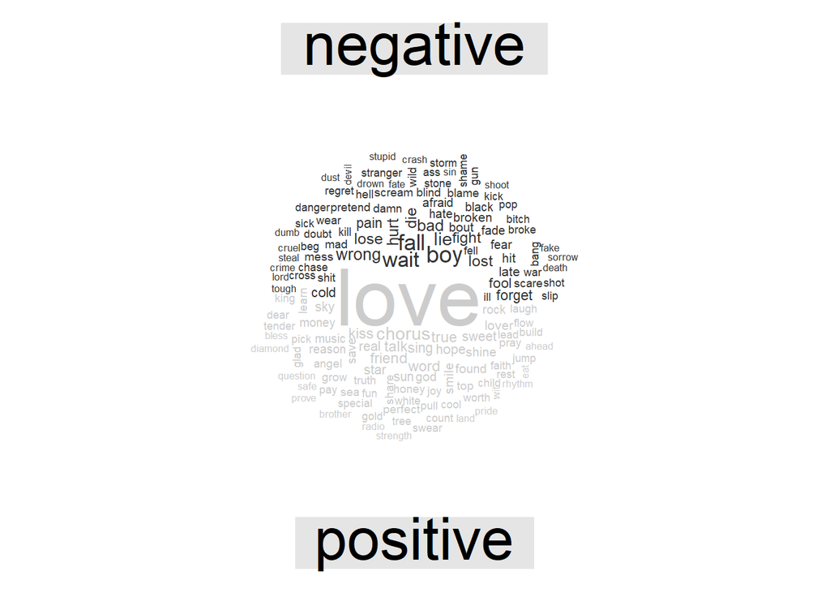

# Do artists use more positive words in their lyrics?

In this part, I would like to analyze for different types of musics, do artists use more positive words or more negative words in their lyrics?

Those figures are ploted based on the difference between frequence of positive words and negative word. Unintuitively, for all types of musics, almost all artists use more negative words in their songs.

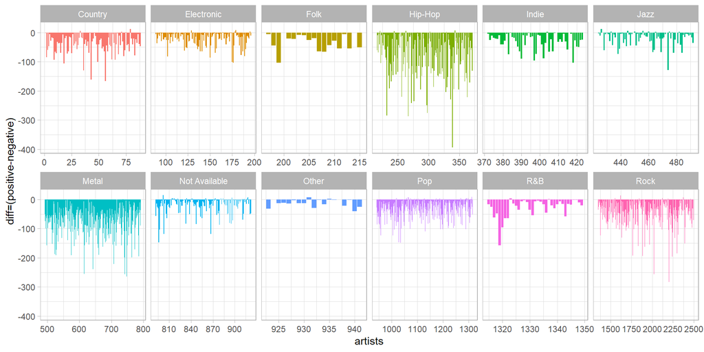

# Summary

- For Pop music, “Love” is always the most frequently used word. However, positive words are not.
- In different genres, almost all artists use more negative words in their lyrics.